# Pràctica de visualització de dades: PART 1

Aïda Piñol Noguero

25/5/2022

[figure not shown]

## **1. Selecció del conjunt de dades:**

### a. Objectiu:

L’objectiu d’aquesta selecció és posar en pràctica els coneixements treballats al llarg de l’assignatura, per tal de crear una visualització que integri diferents elements de forma coherent, d’acord al tipus de dades i a les seves característiques.

### b. Fonts de dades:

El joc de dades utilitzat és el dataset “Complete Pokemon Dataset (Updated 16.04.21)”, descarregat de Kaggle.

### c. Preparació:

Carreguem el fitxer de dades.

```r
pokemon <- read.csv('pokedex.csv',stringsAsFactors = FALSE)
```

Procedim a visualitzar l’estructura i resum del joc de dades principal.

```r
str(pokemon)
```

```
## 'data.frame':    1045 obs. of  51 variables:
##  $ X               : int  0 1 2 3 4 5 6 7 8 9 ...
##  $ pokedex_number  : int  1 2 3 3 4 5 6 6 6 7 ...
##  $ name            : chr  "Bulbasaur" "Ivysaur" "Venusaur" "Mega Venusaur" ...
##  $ german_name     : chr  "Bisasam" "Bisaknosp" "Bisaflor" "Bisaflor" ...
##  $ japanese_name   : chr  "ãƒ•ã‚·ã‚®ãƒ\200ãƒ\215 (Fushigidane)" "ãƒ•ã‚·ã‚®ã‚½ã‚¦ (Fushigisou)" "ãƒ•ã‚·ã‚®ãƒ\220ãƒŠ (Fushigibana)" "ãƒ•ã‚·ã‚®ãƒ\220ãƒŠ (Fushigibana)" ...
##  $ generation      : int  1 1 1 1 1 1 1 1 1 1 ...
##  $ status          : chr  "Normal" "Normal" "Normal" "Normal" ...
##  $ species         : chr  "Seed PokÃ©mon" "Seed PokÃ©mon" "Seed PokÃ©mon" "Seed PokÃ©mon" ...
##  $ type_number     : int  2 2 2 2 1 1 2 2 2 1 ...
##  $ type_1          : chr  "Grass" "Grass" "Grass" "Grass" ...
##  $ type_2          : chr  "Poison" "Poison" "Poison" "Poison" ...
##  $ height_m        : num  0.7 1 2 2.4 0.6 1.1 1.7 1.7 1.7 0.5 ...
##  $ weight_kg       : num  6.9 13 100 155.5 8.5 ...
##  $ abilities_number: int  2 2 2 1 2 2 2 1 1 2 ...
```

[output cut: 37 more lines]

S’obtenen 1045 observacions i 51 variables.

```r
summary(pokemon)
```

```
##        X        pokedex_number      name           german_name
##  Min.   :   0   Min.   :  1.0   Length:1045        Length:1045
##  1st Qu.: 261   1st Qu.:212.0   Class :character   Class :character
##  Median : 522   Median :436.0   Mode  :character   Mode  :character
##  Mean   : 522   Mean   :440.8
##  3rd Qu.: 783   3rd Qu.:670.0
##  Max.   :1044   Max.   :898.0
##
##  japanese_name        generation       status            species
##  Length:1045        Min.   :1.000   Length:1045        Length:1045
##  Class :character   1st Qu.:2.000   Class :character   Class :character
##  Mode  :character   Median :4.000   Mode  :character   Mode  :character
##                     Mean   :4.099
##                     3rd Qu.:6.000
##                     Max.   :8.000
##
##   type_number       type_1             type_2             height_m
##  Min.   :1.000   Length:1045        Length:1045        Min.   :  0.100
##  1st Qu.:1.000   Class :character   Class :character   1st Qu.:  0.600
##  Median :2.000   Mode  :character   Mode  :character   Median :  1.000
##  Mean   :1.529                                         Mean   :  1.374
##  3rd Qu.:2.000                                         3rd Qu.:  1.600
##  Max.   :2.000                                         Max.   :100.000
##
##    weight_kg      abilities_number  ability_1          ability_2
##  Min.   :  0.10   Min.   :0.000    Length:1045        Length:1045
##  1st Qu.:  9.00   1st Qu.:2.000    Class :character   Class :character
##  Median : 29.50   Median :2.000    Mode  :character   Mode  :character
##  Mean   : 71.22   Mean   :2.269
##  3rd Qu.: 70.50   3rd Qu.:3.000
##  Max.   :999.90   Max.   :3.000
##  NA's   :1
##  ability_hidden      total_points          hp             attack
##  Length:1045        Min.   : 175.0   Min.   :  1.00   Min.   :  5.00
##  Class :character   1st Qu.: 330.0   1st Qu.: 50.00   1st Qu.: 55.00
##  Mode  :character   Median : 458.0   Median : 68.00   Median : 77.00
##                     Mean   : 439.4   Mean   : 70.07   Mean   : 80.48
##                     3rd Qu.: 515.0   3rd Qu.: 82.00   3rd Qu.:100.00
##                     Max.   :1125.0   Max.   :255.00   Max.   :190.00
##
```

[output cut: 49 more lines]

```
##  Min.   :0.0000   Min.   :0.250   Min.   :0.000   Min.   :0.000
##  1st Qu.:0.5000   1st Qu.:1.000   1st Qu.:1.000   1st Qu.:1.000
##  Median :1.0000   Median :1.000   Median :1.000   Median :1.000
##  Mean   :0.9981   Mean   :1.238   Mean   :1.019   Mean   :0.977
##  3rd Qu.:1.0000   3rd Qu.:2.000   3rd Qu.:1.000   3rd Qu.:1.000
##  Max.   :4.0000   Max.   :4.000   Max.   :4.000   Max.   :2.000
##
##   against_dark   against_steel    against_fairy
##  Min.   :0.250   Min.   :0.0000   Min.   :0.000
##  1st Qu.:1.000   1st Qu.:0.5000   1st Qu.:1.000
##  Median :1.000   Median :1.0000   Median :1.000
##  Mean   :1.071   Mean   :0.9816   Mean   :1.091
##  3rd Qu.:1.000   3rd Qu.:1.0000   3rd Qu.:1.000
##  Max.   :4.000   Max.   :4.0000   Max.   :4.000
##
```

Així doncs, en l’apartat 2, intentarem reduir la grandària d’aquesta mostra i seleccionarem només les variables objecte d’interès per tal de donar resposta al nostre objectiu d’anàlisi, és a dir, a les preguntes que intentarem respondre i que definirem a continuació.

### d. Exemples i propostes:

Dades que poden generar visualitzacions interessants:

En termes generals, es buscarà analitzar les característiques més definitòries dels pokémons, buscant relacions entre es diferents tipologies d’aquests. Així doncs, la visualització adoptarà un caràcter descriptiu i comparatiu entre les classes de pokémons.

Possibles propostes:

- Relació de tipus de pokémon i pes/ alçada.
- Relació entre tipus i atac/defensa/velocitat…
- Relació entre l’avantatge que presenten sobre altres tipologies.

## **2. Creació de la visualització:**

### a. Plantejament de preguntes:

- *A qui va dirigida la visualització?*

Al tractar-se d’una visualització de caràcter didàctic, ja que l’objectiu és posar en pràctica diferents tipus de gràfiques i eines de visualització, no té un target específic, tot i que sí que és veritat que aquesta resultarà més interessant si es tenen coneixements previs del joc de rol.

- *Què vull respondre amb la visualització?*

Es busca un anàlisis descriptiu dels trets més característics i definitoris dels pokémons. Per tant, les preguntes seran del tipus: Quants tipus de Pokémon hi ha? Quines habilitats s’associen a cada espècie? Quines diferencies de pes i alçada existeixen? Quina relació hi ha entre els Pokémon llegendaris i les estadístiques base?, etc.

- *El dataset em permet contestar-les amb precisió?*

Si, ja que aquest és idoni al comptar amb un tamany més que suficient.

- *Quines dades concretes del meu conjunt de dades vull explorar?*

S’exploraran les variables:

species: la categoria dels Pokémon

type_1: el tipus principal del Pokémon

height_m: alçada del Pokémon en metres

weight_kg: el pes del Pokémon en kilograms

abilities_number: el nombre d’habilitats del Pokémon

total_points: nombre total de punts base

hp: l’HP base del Pokémon

attack: l’atac base del Pokémon

defense: la defensa base del Pokémon

sp_attack: l’atac especial bàsic del Pokémon

sp_defense: la defensa especial base del Pokémon

speed: la velocitat base del Pokémon

catch_rate: taxa de captura del Pokémon

base_friendship: l’amistat base del Pokémon

base_experience: l’experiència bàsica d’un Pokémon salvatge quan és atrapat

growth_rate: la taxa de creixement del Pokémon

percentage_male: el percentatge de les espècies que són mascles

egg_cycles: el nombre de cicles (255-257 passos) necessaris per eclosionar un ou

against_normal: multiplicador que s’aplica quan el dany prové d’un Pokémon normal

against_fire: multiplicador que s’aplica quan el dany prové d’un Pokémon tipus foc

against_water: multiplicador que s’aplica quan el dany prové d’un Pokémon tipus aigua

against_electric: multiplicador que s’aplica quan el dany prové d’un Pokémon elèctric

against_grass: multiplicador que s’aplica quan el dany prové d’un Pokémon tipus herba

against_ice: multiplicador que s’aplica quan el dany prové d’un Pokémon tipus gel

against_fight: multiplicador que s’aplica quan el dany prové d’un Pokémon tipus lluita

against_poison: multiplicador que s’aplica quan el dany prové d’un Pokémon tipus verí

against_ground: multiplicador que s’aplica quan el dany prové d’un Pokémon tipus terra

against_flying: multiplicador que s’aplica quan el dany prové d’un Pokémon volador

against_psychic: multiplicador que s’aplica quan el dany prové d’un Pokémon psíquic

against_bug: multiplicador que s’aplica quan el dany prové d’un Pokémon tipus insecte

against_rock: multiplicador que s’aplica quan el dany prové d’un Pokémon tipus roca

against_gosth: multiplicador que s’aplica quan el dany prové d’un Pokémon fantasma

against_dragon: multiplicador que s’aplica quan el dany prové d’un Pokémon tipus drac

against_dark: multiplicador que s’aplica quan el dany prové d’un Pokémon tipus fosc

against_steel: multiplicador que s’aplica quan el dany prové d’un Pokémon tipus acer

against_fairy: multiplicador que s’aplica quan el dany prové d’un Pokémon tipus fada

- *Necessito més fonts de dades per donar context al meu conjunt de dades?*

Tot i que amb les diferents variables del dataset podem contestar a les preguntes principals, finalment s’ha requerit una informació addicional, provinent de la pàgina web https://pokemon.fandom.com/es/wiki/Gimnasio_Pok%C3%A9mon_de_Ciudad_Plateada.

### b. Exploració de les dades:

**Tasca de neteja o condicionant**

En primer lloc, buquem els valors nuls i els valors buits:

**Estadístiques de valors nuls.**

```r
colSums(is.na(pokemon))
```

```
##                X   pokedex_number             name      german_name
##                0                0                0                0
##    japanese_name       generation           status          species
##                0                0                0                0
##      type_number           type_1           type_2         height_m
##                0                0                0                0
##        weight_kg abilities_number        ability_1        ability_2
##                1                0                0                0
##   ability_hidden     total_points               hp           attack
##                0                0                0                0
##          defense        sp_attack       sp_defense            speed
##                0                0                0                0
##       catch_rate  base_friendship  base_experience      growth_rate
##               18              115              120                0
##  egg_type_number       egg_type_1       egg_type_2  percentage_male
##                0                0                0              173
##       egg_cycles   against_normal     against_fire    against_water
##                1                0                0                0
## against_electric    against_grass      against_ice    against_fight
##                0                0                0                0
##   against_poison   against_ground   against_flying  against_psychic
##                0                0                0                0
##      against_bug     against_rock    against_ghost   against_dragon
##                0                0                0                0
##     against_dark    against_steel    against_fairy
##                0                0                0
```

**Estadístiques de valors buits.**

```r
colSums(pokemon=="")
```

```
##                X   pokedex_number             name      german_name
##                0                0                0                0
##    japanese_name       generation           status          species
##                0                0                0                0
##      type_number           type_1           type_2         height_m
##                0                0              492                0
##        weight_kg abilities_number        ability_1        ability_2
##               NA                0                3              529
##   ability_hidden     total_points               hp           attack
##              232                0                0                0
##          defense        sp_attack       sp_defense            speed
##                0                0                0                0
##       catch_rate  base_friendship  base_experience      growth_rate
##               NA               NA               NA                1
##  egg_type_number       egg_type_1       egg_type_2  percentage_male
##                0                3              760               NA
##       egg_cycles   against_normal     against_fire    against_water
##               NA                0                0                0
## against_electric    against_grass      against_ice    against_fight
##                0                0                0                0
##   against_poison   against_ground   against_flying  against_psychic
##                0                0                0                0
##      against_bug     against_rock    against_ghost   against_dragon
##                0                0                0                0
##     against_dark    against_steel    against_fairy
##                0                0                0
```

Assignem el valor “NA” als valors buits del dataset:

```r
pokemon[pokemon == ""]<- NA
```

Obtenim el % de valors nuls per columnes:

```r
colMeans(is.na(pokemon))
```

```
##                X   pokedex_number             name      german_name
##     0.0000000000     0.0000000000     0.0000000000     0.0000000000
##    japanese_name       generation           status          species
##     0.0000000000     0.0000000000     0.0000000000     0.0000000000
##      type_number           type_1           type_2         height_m
##     0.0000000000     0.0000000000     0.4708133971     0.0000000000
##        weight_kg abilities_number        ability_1        ability_2
##     0.0009569378     0.0000000000     0.0028708134     0.5062200957
##   ability_hidden     total_points               hp           attack
##     0.2220095694     0.0000000000     0.0000000000     0.0000000000
##          defense        sp_attack       sp_defense            speed
##     0.0000000000     0.0000000000     0.0000000000     0.0000000000
##       catch_rate  base_friendship  base_experience      growth_rate
##     0.0172248804     0.1100478469     0.1148325359     0.0009569378
##  egg_type_number       egg_type_1       egg_type_2  percentage_male
##     0.0000000000     0.0028708134     0.7272727273     0.1655502392
##       egg_cycles   against_normal     against_fire    against_water
##     0.0009569378     0.0000000000     0.0000000000     0.0000000000
## against_electric    against_grass      against_ice    against_fight
##     0.0000000000     0.0000000000     0.0000000000     0.0000000000
##   against_poison   against_ground   against_flying  against_psychic
##     0.0000000000     0.0000000000     0.0000000000     0.0000000000
##      against_bug     against_rock    against_ghost   against_dragon
##     0.0000000000     0.0000000000     0.0000000000     0.0000000000
##     against_dark    against_steel    against_fairy
##     0.0000000000     0.0000000000     0.0000000000
```

Visualitzem les columnes amb els valors NULS més grans o iguals al 15%:

```r
cols_borrar <- which(colMeans(is.na(pokemon)) >= 0.15)
cols_borrar
```

```
##          type_2       ability_2  ability_hidden      egg_type_2 percentage_male
##              11              16              17              31              32
```

```r
pokemon <- pokemon[,-which(colMeans(is.na(pokemon)) >= 0.20)]
```

## Anàlisi exploratòria:

**Anàlisi de variables categòriques (tipus de Pokémon):**

- Tipus primari (type_1):

```r
# Obtenim els diferents tipus primaris en que es classifiquen els Pokémon:
unique(pokemon$type_1)
```

```
##  [1] "Grass"    "Fire"     "Water"    "Bug"      "Normal"   "Dark"
##  [7] "Poison"   "Electric" "Ground"   "Ice"      "Fairy"    "Steel"
## [13] "Fighting" "Psychic"  "Rock"     "Ghost"    "Dragon"   "Flying"
```

```r
length(unique(pokemon$type_1))
```

```
## [1] 18
```

Obtenim 18 tipus diferents de pokémons. Aquesta serà la variable objecte d’estudi principal, ja que ens servirà per buscar relacions amb altres variables per treballar diferents tipus de visualitzacions.

### c. Disseny: com representar les dades

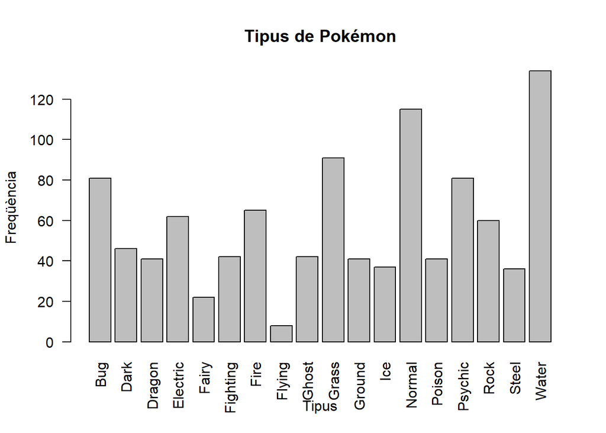

```r
# Exemple de visualització:
barplot(table(pokemon$type_1),main="Tipus de Pokémon",ylab="Freqüència",xlab="Tipus",las=2)
```

Segons el tipus de variables utilitzades (si són categòriques, numèriques o booleanes) generarem un tipus de visualització o un altre. Per a fer-ho, utilitzarem diferents eines com Flourish o Infogram.

Un element que vull incloure és una visualització que representa l’avantatge que presenta un tipus de Pokémon sobre un altre, inspirat en el diagrama següent, pubicat a reddit per l’usuari u/r_noob:

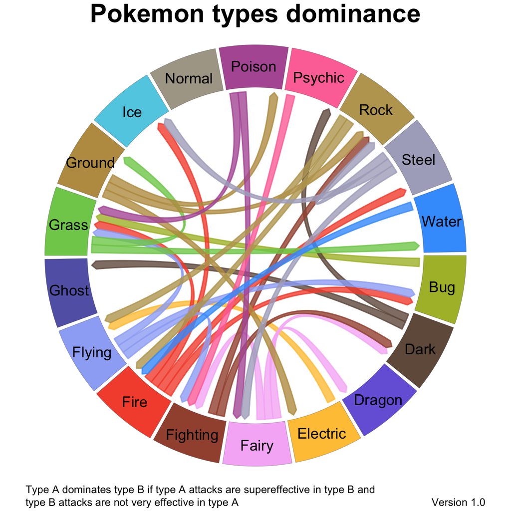

Finalment, s’han emprat diagrames de barres, diagrama de barres apilades, diagrama de cordes i de jerarquía, gràfic de radar i gràfics de dispersió.

### d. El procés de visualització

En aquesta darrera pràctica, el meu projecte adoptarà la forma DE PRESENTACIÓ, per tant, la lectura serà horitzontal i integrarà els diferents elements generats amb diverses eines treballades al llarg de l’assignatura.